# Shashi_proj5_Credit_Card_Customer_Segmentation

### Silhouette Score

```python
silhouette_score(cData_z_Scaled, model.labels_)
```

```
0.5026435522438492
```

```python
#Just using a different coloum name Labels instead of GROUP.
cData['labels'] = model.labels_
cData_z_Scaled['labels'] = model.labels_
cData.head(10)
```

|  | Avg_Credit_Limit | Total_Credit_Cards | Total_visits_bank | Total_visits_online | Total_calls_made | labels |
| --- | --- | --- | --- | --- | --- | --- |
| 0 | 100000 | 2 | 1 | 1 | 0 | 0 |
| 1 | 50000 | 3 | 0 | 10 | 9 | 2 |
| 2 | 50000 | 7 | 1 | 3 | 4 | 0 |
| 3 | 30000 | 5 | 1 | 1 | 4 | 0 |
| 4 | 100000 | 6 | 0 | 12 | 3 | 1 |
| 5 | 20000 | 3 | 0 | 1 | 8 | 2 |
| 6 | 100000 | 5 | 0 | 11 | 2 | 1 |
| 7 | 15000 | 3 | 0 | 1 | 1 | 0 |
| 8 | 5000 | 2 | 0 | 2 | 2 | 0 |
| 9 | 3000 | 4 | 0 | 1 | 7 | 2 |

```python
cDataClust = cData.groupby(['labels'])
cDataClust.mean()
```

| labels | Avg_Credit_Limit | Total_Credit_Cards | Total_visits_bank | Total_visits_online | Total_calls_made |
| --- | --- | --- | --- | --- | --- |
| 0 | 33151.133501 | 5.460957 | 3.405542 | 1.010076 | 2.060453 |
| 1 | 141040.000000 | 8.740000 | 0.600000 | 10.900000 | 1.080000 |
| 2 | 12234.741784 | 2.352113 | 0.957746 | 3.633803 | 7.009390 |

```
array([[<matplotlib.axes._subplots.AxesSubplot object at 0x000002B535C5E430>,
      dtype=object)
```

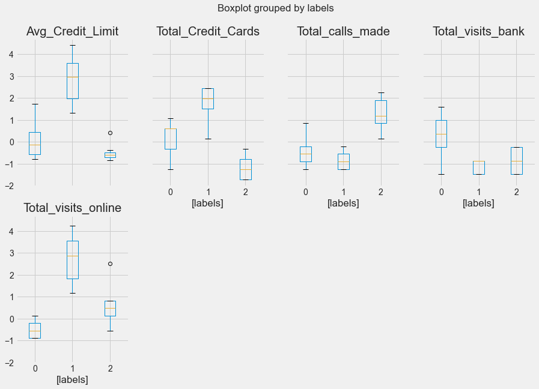

```python
cData_z_Scaled.boxplot(by='labels', layout = (2,4),figsize=(15,10))
```

```python
#Lets do Hierarchical Clustering (ward) with 3 clusters.
cData.drop('labels', axis=1, inplace=True)
cData_z_Scaled.drop('labels', axis=1, inplace=True)
model = AgglomerativeClustering(n_clusters=3, affinity='euclidean',  linkage='ward')
model.fit(cData_z_Scaled)
```

```
AgglomerativeClustering(n_clusters=3)
```

### Silhouette Score

```python
silhouette_score(cData_z_Scaled, model.labels_)
```

```
0.5147639589977819
```

```python
#Just using a different coloum name Labels instead of GROUP.
cData['labels'] = model.labels_
cData_z_Scaled['labels'] = model.labels_
cData.head(10)
```

|  | Avg_Credit_Limit | Total_Credit_Cards | Total_visits_bank | Total_visits_online | Total_calls_made | labels |
| --- | --- | --- | --- | --- | --- | --- |
| 0 | 100000 | 2 | 1 | 1 | 0 | 0 |
| 1 | 50000 | 3 | 0 | 10 | 9 | 1 |
| 2 | 50000 | 7 | 1 | 3 | 4 | 0 |
| 3 | 30000 | 5 | 1 | 1 | 4 | 0 |
| 4 | 100000 | 6 | 0 | 12 | 3 | 2 |
| 5 | 20000 | 3 | 0 | 1 | 8 | 1 |
| 6 | 100000 | 5 | 0 | 11 | 2 | 2 |
| 7 | 15000 | 3 | 0 | 1 | 1 | 1 |
| 8 | 5000 | 2 | 0 | 2 | 2 | 1 |
| 9 | 3000 | 4 | 0 | 1 | 7 | 1 |

```python
cDataClust = cData.groupby(['labels'])
cDataClust.mean()
```

| labels | Avg_Credit_Limit | Total_Credit_Cards | Total_visits_bank | Total_visits_online | Total_calls_made |
| --- | --- | --- | --- | --- | --- |
| 0 | 33851.948052 | 5.516883 | 3.493506 | 0.979221 | 1.994805 |
| 1 | 12151.111111 | 2.422222 | 0.937778 | 3.546667 | 6.857778 |
| 2 | 141040.000000 | 8.740000 | 0.600000 | 10.900000 | 1.080000 |

```
array([[<matplotlib.axes._subplots.AxesSubplot object at 0x000002B5383E0FD0>,
      dtype=object)
```

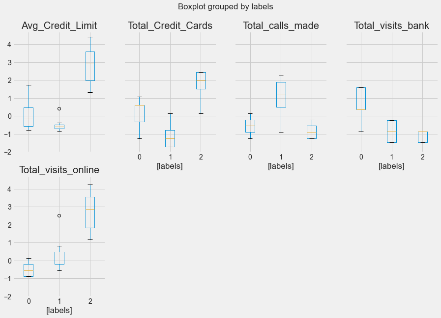

```python
cData_z_Scaled.boxplot(by='labels', layout = (2,4),figsize=(15,10))
```

### Silhouette Score

```
K-Means Clustering: For n_clusters = 2 The average silhouette_score is : 0.41842496663215445
Hierarchical Clustering: For n_clusters = 2 The average silhouette_score is : 0.5703183487340514
K-Means Clustering: For n_clusters = 3 The average silhouette_score is : 0.5157182558881063
Hierarchical Clustering: For n_clusters = 3 The average silhouette_score is : 0.515922432650965
K-Means Clustering: For n_clusters = 4 The average silhouette_score is : 0.3556670619372605
Hierarchical Clustering: For n_clusters = 4 The average silhouette_score is : 0.47495143595793504
```

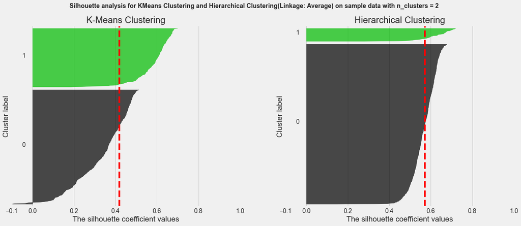

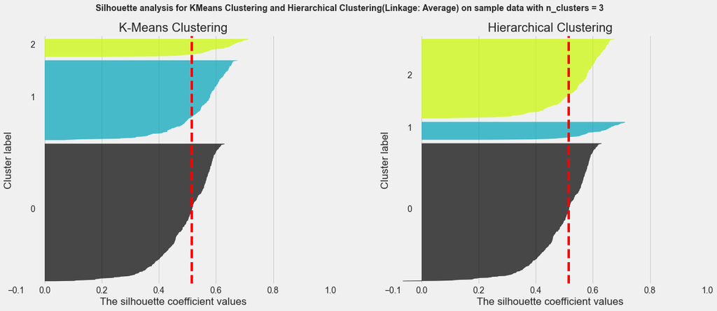

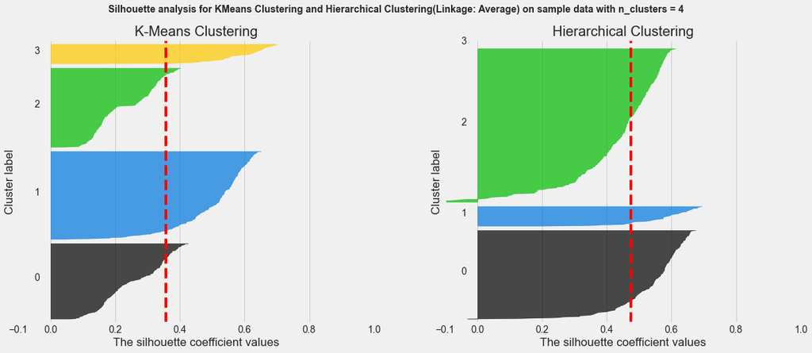

```python
from sklearn.metrics import silhouette_samples
import matplotlib.cm as cm

cData.drop('labels', axis=1, inplace=True)
cData_z_Scaled.drop('labels', axis=1, inplace=True)

range_n_clusters=range(2,5)
X = cData_z_Scaled
for n_clusters in range_n_clusters:
    # Create a subplot with 1 row and 2 columns
    fig, (ax1, ax2) = plt.subplots(1, 2)
    fig.set_size_inches(18, 7)

    # The 1st subplot is the silhouette plot
    # The silhouette coefficient can range from -1, 1 but in this example all
    # lie within [-0.1, 1]
    ax1.set_xlim([-0.1, 1])
    # The (n_clusters+1)*10 is for inserting blank space between silhouette
    # plots of individual clusters, to demarcate them clearly.
    ax1.set_ylim([0, len(X) + (n_clusters + 1) * 10])

    # Initialize the clusterer with n_clusters value and a random generator
    # seed of 10 for reproducibility.
    clusterer = KMeans(n_clusters=n_clusters, random_state=10)
    cluster_labels = clusterer.fit_predict(X)

    # The silhouette_score gives the average value for all the samples.
    # This gives a perspective into the density and separation of the formed
    # clusters
    silhouette_avg = silhouette_score(X, cluster_labels)
    print("K-Means Clustering: For n_clusters =", n_clusters,
          "The average silhouette_score is :", silhouette_avg)

    # Compute the silhouette scores for each sample
    sample_silhouette_values = silhouette_samples(X, cluster_labels)

    y_lower = 10
    for i in range(n_clusters):
        # Aggregate the silhouette scores for samples belonging to
        # cluster i, and sort them
        ith_cluster_silhouette_values = \
            sample_silhouette_values[cluster_labels == i]

        ith_cluster_silhouette_values.sort()

        size_cluster_i = ith_cluster_silhouette_values.shape[0]
        y_upper = y_lower + size_cluster_i

        color = cm.nipy_spectral(float(i) / n_clusters)
        ax1.fill_betweenx(np.arange(y_lower, y_upper),
                          0, ith_cluster_silhouette_values,
                          facecolor=color, edgecolor=color, alpha=0.7)

        # Label the silhouette plots with their cluster numbers at the middle
        ax1.text(-0.05, y_lower + 0.5 * size_cluster_i, str(i))

        # Compute the new y_lower for next plot
        y_lower = y_upper + 10  # 10 for the 0 samples

    ax1.set_title("K-Means Clustering")
    ax1.set_xlabel("The silhouette coefficient values")
    ax1.set_ylabel("Cluster label")

    # The vertical line for average silhouette score of all the values
    ax1.axvline(x=silhouette_avg, color="red", linestyle="--")

    ax1.set_yticks([])  # Clear the yaxis labels / ticks
    ax1.set_xticks([-0.1, 0, 0.2, 0.4, 0.6, 0.8, 1])


    # The 2nd subplot is the silhouette plot
    # The silhouette coefficient can range from -1, 1 but in this example all
    # lie within [-0.1, 1]
    ax2.set_xlim([-0.1, 1])
    # The (n_clusters+1)*10 is for inserting blank space between silhouette
    # plots of individual clusters, to demarcate them clearly.
    ax2.set_ylim([0, len(X) + (n_clusters + 1) * 10])

    # Initialize the clusterer with n_clusters value and a random generator
    # seed of 10 for reproducibility.
    clusterer = AgglomerativeClustering(n_clusters=n_clusters, affinity='euclidean',  linkage='average')
    cluster_labels = clusterer.fit_predict(X)

    # The silhouette_score gives the average value for all the samples.
    # This gives a perspective into the density and separation of the formed
    # clusters
    silhouette_avg = silhouette_score(X, cluster_labels)
    print("Hierarchical Clustering: For n_clusters =", n_clusters,
          "The average silhouette_score is :", silhouette_avg)

    # Compute the silhouette scores for each sample
    sample_silhouette_values = silhouette_samples(X, cluster_labels)

    y_lower = 10
    for i in range(n_clusters):
        # Aggregate the silhouette scores for samples belonging to
        # cluster i, and sort them
        ith_cluster_silhouette_values = \
            sample_silhouette_values[cluster_labels == i]

        ith_cluster_silhouette_values.sort()

        size_cluster_i = ith_cluster_silhouette_values.shape[0]
        y_upper = y_lower + size_cluster_i

        color = cm.nipy_spectral(float(i) / n_clusters)
        ax2.fill_betweenx(np.arange(y_lower, y_upper),
                          0, ith_cluster_silhouette_values,
                          facecolor=color, edgecolor=color, alpha=0.7)

        # Label the silhouette plots with their cluster numbers at the middle
        ax2.text(-0.05, y_lower + 0.5 * size_cluster_i, str(i))

        # Compute the new y_lower for next plot
        y_lower = y_upper + 10  # 10 for the 0 samples

    ax2.set_title("Hierarchical Clustering")
    ax2.set_xlabel("The silhouette coefficient values")
    ax2.set_ylabel("Cluster label")

    # The vertical line for average silhouette score of all the values
    ax2.axvline(x=silhouette_avg, color="red", linestyle="--")

    ax2.set_yticks([])  # Clear the yaxis labels / ticks
    ax2.set_xticks([-0.1, 0, 0.2, 0.4, 0.6, 0.8, 1])

    plt.suptitle(("Silhouette analysis for KMeans Clustering and Hierarchical Clustering(Linkage: Average) on sample data "
                  "with n_clusters = %d" % n_clusters),
                 fontsize=14, fontweight='bold')

plt.show()
```

### Compare K-means clusters with Hierarchical clusters

```python
final_model=KMeans(3)
final_model.fit(cData_z_Scaled)
prediction=final_model.predict(cData_z_Scaled)
#Append the prediction
cData["GROUP"] = prediction
cData_z_Scaled["GROUP"] = prediction
cDataClust = cData.groupby(['GROUP'])
cDataClust.mean()
```

| GROUP | Avg_Credit_Limit | Total_Credit_Cards | Total_visits_bank | Total_visits_online | Total_calls_made |
| --- | --- | --- | --- | --- | --- |
| 0 | 12174.107143 | 2.410714 | 0.933036 | 3.553571 | 6.870536 |
| 1 | 141040.000000 | 8.740000 | 0.600000 | 10.900000 | 1.080000 |
| 2 | 33782.383420 | 5.515544 | 3.489637 | 0.981865 | 2.000000 |

```python
cData.drop('GROUP', axis=1, inplace=True)
cData_z_Scaled.drop('GROUP', axis=1, inplace=True)
model = AgglomerativeClustering(n_clusters=3, affinity='euclidean',  linkage='average')
model.fit(cData_z_Scaled)
cData['labels'] = model.labels_
cData_z_Scaled['labels'] = model.labels_
cDataClust = cData.groupby(['labels'])
cDataClust.mean()
```

| labels | Avg_Credit_Limit | Total_Credit_Cards | Total_visits_bank | Total_visits_online | Total_calls_made |
| --- | --- | --- | --- | --- | --- |
| 0 | 33713.178295 | 5.511628 | 3.485788 | 0.984496 | 2.005168 |
| 1 | 141040.000000 | 8.740000 | 0.600000 | 10.900000 | 1.080000 |
| 2 | 12197.309417 | 2.403587 | 0.928251 | 3.560538 | 6.883408 |

```python
cData.drop('labels', axis=1, inplace=True)
cData_z_Scaled.drop('labels', axis=1, inplace=True)
model = AgglomerativeClustering(n_clusters=3, affinity='euclidean',  linkage='complete')
model.fit(cData_z_Scaled)
cData['labels'] = model.labels_
cData_z_Scaled['labels'] = model.labels_
cDataClust = cData.groupby(['labels'])
cDataClust.mean()
```

| labels | Avg_Credit_Limit | Total_Credit_Cards | Total_visits_bank | Total_visits_online | Total_calls_made |
| --- | --- | --- | --- | --- | --- |
| 0 | 33151.133501 | 5.460957 | 3.405542 | 1.010076 | 2.060453 |
| 1 | 141040.000000 | 8.740000 | 0.600000 | 10.900000 | 1.080000 |
| 2 | 12234.741784 | 2.352113 | 0.957746 | 3.633803 | 7.009390 |

```python
cData.drop('labels', axis=1, inplace=True)
cData_z_Scaled.drop('labels', axis=1, inplace=True)
model = AgglomerativeClustering(n_clusters=3, affinity='euclidean',  linkage='ward')
model.fit(cData_z_Scaled)
cData['labels'] = model.labels_
cData_z_Scaled['labels'] = model.labels_
cDataClust = cData.groupby(['labels'])
cDataClust.mean()
```

| labels | Avg_Credit_Limit | Total_Credit_Cards | Total_visits_bank | Total_visits_online | Total_calls_made |
| --- | --- | --- | --- | --- | --- |
| 0 | 33851.948052 | 5.516883 | 3.493506 | 0.979221 | 1.994805 |
| 1 | 12151.111111 | 2.422222 | 0.937778 | 3.546667 | 6.857778 |
| 2 | 141040.000000 | 8.740000 | 0.600000 | 10.900000 | 1.080000 |

As we have seen in the above, the results of both the clustering are almost similar. They are all clustered around average credit limit of 30,000, 12,000 and 140,000. However, along with many similarities, these two techniques have some differences also. The below table shows the comparison between K-Means and Hierarchical clustering algorithms based on our implementations.

|  | **K-Means Clustering** | **Hierarchical Clustering** |
| --- | --- | --- |
| **Category** | Centroid based, partition-based | Hierarchical, Agglomerative |
| **Method to find the optimal number of clusters** | The Elbow method | Dendrogram |
| **Directional approach** | Not any, the only centroid is considered to form clusters | Top-down, bottom-up |
| **Python Library** | sklearn – KMeans | sklearn-AgglomerativeClustering |

### Analyse the clusters formed

Tell us how is one cluster different from another  
Key Questions:

1. How many different segments of customers are there?
2. How are these segments different from each other?
3. What are your recommendations to the bank on how to better market to and service these customers?

There are 3 segments (High Credit($140,000), Average Credit (30,000), Low Credit(12,000))

1. Customers who have average credit limit (30,000) who have 5 to 6 credit cards on average, they visit the bank 3 to 4 times and visity online 1 time the bank has made 2 call on average to them.
2. Customers who have high credit limit (140,000) who have 8 to 9 credit cards and they visit online banking (11 Times) than the in person. Bank has called the very less on the average 1 call.
3. Customers who have a modest credit limit (12,000) they visit the bank 1 time and they visit online 3 to 4 times. The bank has called them more times (6 to 7) to encorage them open more lines of credit.

Reccomendations:

1)The bank shoud keep calling the Low Credit(12,000) customers to encorage them to open more lines of credit and encorage them to come to the bank more often so that the bank associates can give them more personal attention to entice them to more services on offer. The bank should encourage this customers to go online more as well so that you can give them more offers online as well.

2) The bank should also make more calls to the Average Credit(30,000) customers than the 2 calls that they are making now. The bank should also encourage this group to go online banking more so that you can give them more offers there.

3) The bank should also make more calls to the High Credit(140,000) customers to offer them more services and encorage them to come to bank more often so that the associate can give them more personal attention to show them more services on offer.